# defense

PhD Defense · 2026

The Hippocampal-to-Ventricle Ratio

A self-normalizing biomarker for medial temporal integrity  
across the Alzheimer’s disease continuum

Sofía Fernández-Lozano · Supervisor: Louis Collins

[figure not shown]

[figure not shown]

[figure not shown]

Background

Why HVR exists

The hippocampus in Alzheimer’s disease, and the head-size problem

Background · The disease

Alzheimer’s:  
the leading cause of dementia

55 M cases worldwide  
projected **139 M by 2050**

**Pathology spans multiple systems**  
amyloid · tau · neurodegeneration  
· inflammation · synuclein · vascular  
(2024 NIA-AA **AT₁T₂NISV**).

**Structural MRI** captures *N*  
— the substrate HVR measures.

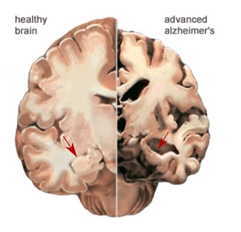

Image: Alzheimer’s Association · Livingston et al., 2024 · Jack et al., 2024

Background · The hippocampus

The reference structural marker

Medial temporal lobe · earliest AD target

The most-used structural MRI biomarker in AD.

Anchors clinical trials, diagnostic frameworks, and longitudinal studies.

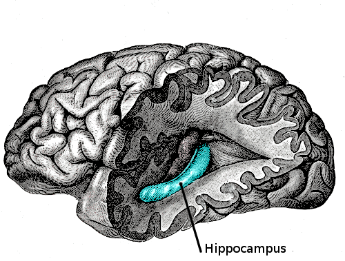

Gray’s Anatomy (Gray739) · Wikimedia Commons

Background · The first problem

HC volume is highly variable

~25%

of healthy young adults have HC volumes  
that overlap with the elderly

Lupien et al., 2007 · Bruno et al., 2016

Background ·  
The methodological problem

No consensus on head-size correction

Same data → different  
—sometimes **reversed**—sex differences

Multiple competing correction methods  
(proportions, residualization, stereotaxic)  
rest on different assumptions.

Decades of conflicting findings  
on whether HC is larger in males or females.

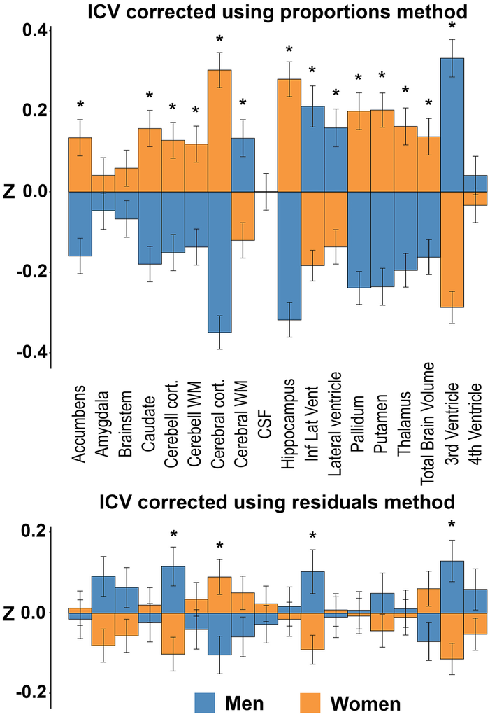

Pintzka et al., 2015 · O’Brien et al., 2011 · Voevodskaya et al., 2014

Background · The proposed solution

HVR: the ratio that self-normalizes

**HVR = HC / (HC + th-CSF)**

As the hippocampus atrophies,  
CSF expands ex vacuo into the space.

Both structures scale with head size  
— the ratio cancels it out.

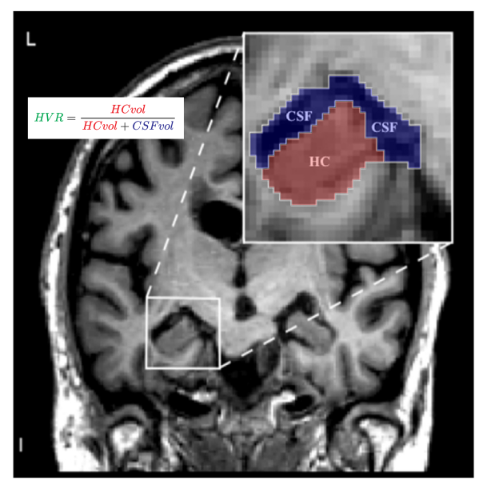

Figure: adapted from Schoemaker et al., 2019 · Bruno et al., 2016

Background · The four chapters

From concept to clinical inference

**Chapter 3** — **Qrater:**  
open-source QC platform that curates the imaging data.

**Chapter 4** — **Automated HVR:**  
CNN segmentation validated against manual labels in ADNI.

**Chapter 5** — **HVR at scale:**  
27,680 UK Biobank participants; sex-specific normative reference.

**Chapter 6** — **HVR in the clinic:**  
apply the normative reference to amyloid-positive ADNI;  
isolate cardiovascular risk from age.

Chapter 3

Qrater

A collaborative and centralized imaging quality-control web application

Fernández-Lozano S, Dadar M, Morrison C, Manera A, Andrews D, Rajabli R, Madge V, St-Onge E, Shaffie N, Livadas A, Fonov VS, Collins DL; for the ADNI. QRATER: a collaborative and centralized imaging quality control web-based application. *Aperture Neuro*. 2024;4. doi:10.52294/001c.118616

Chapter 3 · Motivation

Visual QC was the bottleneck

**The problem**

- Thousands of MRI scans
- Multiple raters in parallel
- Each QC task (raw · registration · segmentation) had its own ad-hoc tool

**Existing tools fell short**

- **Single-user** workflows (VisualQC)
- **Modality-specific** pipelines (MRIQC, pyfMRIQC)
- Dashboards not built for **rating throughput** (Mindcontrol)

Chapter 3 · The tool

Qrater — web-based, containerized, collaborative

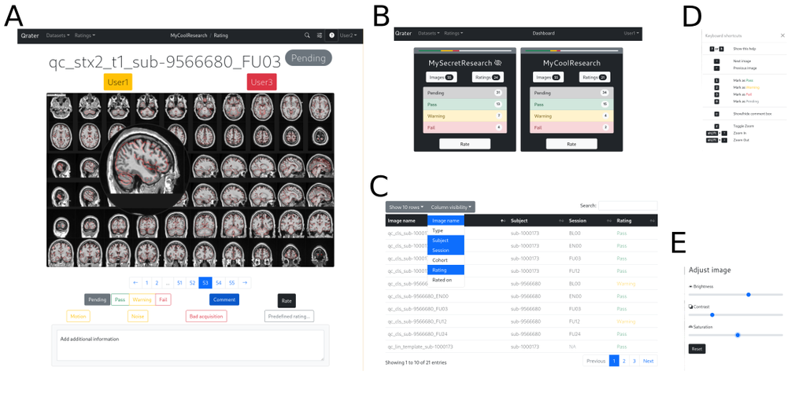

Flask + MySQL + Redis in Docker · rates any 2D rendering · 8+ concurrent users.

Fernández-Lozano, 2024

Chapter 3 · What we tested

Three QC tasks, three mosaic formats

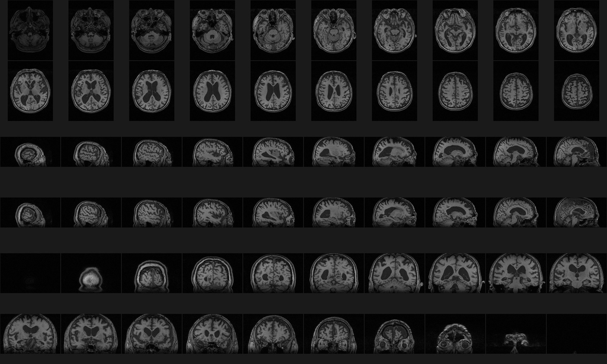

Raw T1w MRI

Native space

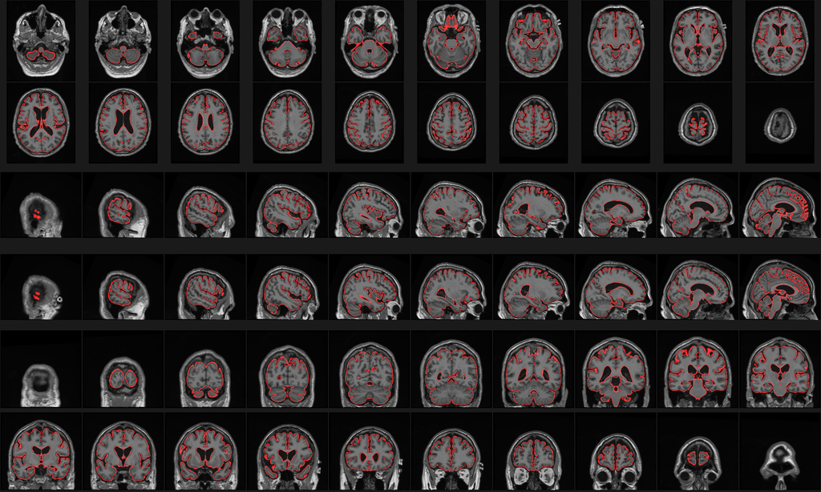

Linear registration

Template overlay in red

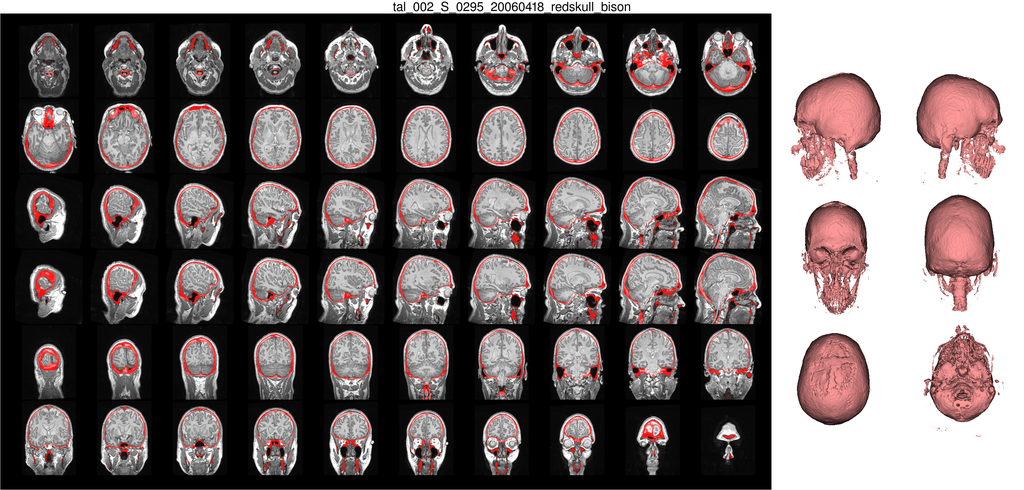

Skull segmentation

Segmentation overlay in red

60-slice mosaic each · 11 raters vs senior-expert gold standard.

Fernández-Lozano, 2024

Chapter 3 · The improvement

Per-task speedup vs conventional viewer

| Task | Rater | Conventional | Qrater | Speedup |
| --- | --- | --- | --- | --- |
| Raw MRI | Expert | 90 imgs / 63 min | 99 imgs / 63 min | **1.1×** |
| Raw MRI | Trainee | 79 imgs / 98 min | 99 imgs / 98 min | **1.3×** |
| Linear registration | Expert | 43 imgs / 36 min | 99 imgs / 36 min | **2.3×** |
| Linear registration | Trainee | 30 imgs / 37 min | 99 imgs / 37 min | **3.3×** |
| Skull segmentation | Expert | ~60 s / image | ~3 s / image | **~20×** |

Chapter 3 · Adoption + tools

Qrater in use beyond this thesis

Released on DockerHub + GitHub

250 K+

images on the lab Qrater instance (current)

Adopted beyond the original project; used by collaborator labs.  
The QC’d ADNI dataset is the foundation for Chapters 4 and 6 of this thesis.

Fernández-Lozano, 2024

Chapter 4

HVR Validation

Automated CNN-based segmentation and clinical benchmarking in ADNI (N = 1,641)

Fernández-Lozano S, Fonov VS, Schoemaker D, Pruessner JC, Potvin O, Duchesne S, Collins DL; for the ADNI. Enhanced Detection of Age-Related and Cognitive Declines Using Automated Hippocampal-to-Ventricle Ratio in Alzheimer’s Patients. *Human Brain Mapping*. 2025;46(11). doi:10.1002/hbm.70265

Chapter 4 · Motivation

Manual segmentation doesn’t scale

2 h

per subject to hand-trace HC + temporal-horn (Schoemaker 2019)

Plus high intra- and inter-rater variability.  
Biobank-scale HVR is infeasible without automation.

Chapter 4 · Design

From 80 manual labels  
to 1,641 clinical scans

Four method families · joint HC + th-CSF

**Training**  
80 manually labelled (Pruessner protocol)  
5-fold CV (64 / 16).

**Out-of-sample** — 60 (CH / MCI / AD).

**Clinical application** — *N* = 1,641 ADNI.

**Compared**  
MALF · NLPB · CNN · FreeSurfer v4.3 / 5.1 / 6.0.

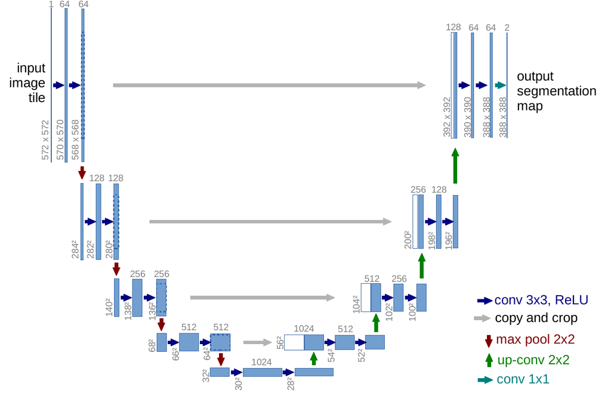

U-Net schematic · Ronneberger et al., 2015

Chapter 4 · Segmentation performance

CNN matches manual at the rater-noise floor

Against 80 manually-segmented labels

**Dice HC** = **0.94–0.96 (0.9)**

**Volume ρ** = **0.97-0.99 (0.90-0.96)**

MALF and NLPB show systematic drift;  
CNN doesn’t.

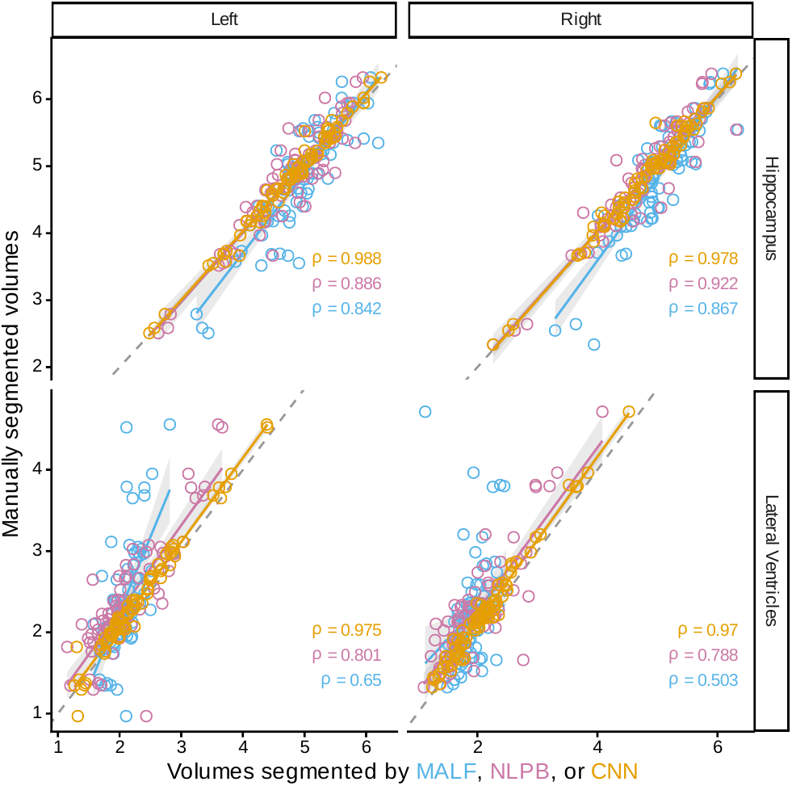

Fernández-Lozano, 2025

Chapter 4 · The defining property

HVR amplifies effect sizes across all methods

CH:AD discrimination · Δ = Cohen’s d

| Segmentation | HCvol Δ | HVR Δ |
| --- | --- | --- |
| **MALF** | **−0.78** | **−1.24** |
| NLPB | −1.54 | −1.73 |
| CNN | −1.85 | −1.86 |
| FreeSurfer v6.0 | −1.76 | −2.02 |

HVR ≥ HCvol for every method · biggest gain where segmentation is weakest (MALF, +59%).

Chapter 4 · Brain–behavior associations

HVR recovers brain–behavior signal HC volume loses

Correlation with age and cognition (Spearman ρ) · AD group

| Segmentation | HCvol–age | HVR–age | HCvol–ADAS | HVR–ADAS |
| --- | --- | --- | --- | --- |
| **MALF** | **−0.03** (n.s.) | **−0.38** | **+0.04** (n.s.) | **−0.30** |
| NLPB | −0.32 | −0.44 | −0.17 | −0.27 |
| CNN | −0.44 | −0.49 | −0.22 | −0.30 |
| FreeSurfer v6.0 | −0.46 | −0.52 | −0.22 | −0.28 |

Both outcomes (cognition by ADAS-13, lower = better) · HVR ≥ HCvol for every method; MALF HCvol n.s. in both · memory (RAVLT) in supp.

Fernández-Lozano, 2025

Chapter 4 · Reliability at scale

CNN holds at biobank scale

0.1%

CNN failure rate on 1,641 ADNI scans

2 failures total · vs MALF 1.5%, FS v4.3/5.1 ~14% missing.  
Pipeline ready for population-scale (Ch5) and clinical longitudinal (Ch6).

Fernández-Lozano, 2025

Chapter 5

Sex Differences in UK Biobank

HVR as a head-size-independent biomarker · N = 27,680 UKB participants

Fernández-Lozano S, Collins DL. Hippocampal-to-Ventricle Ratio as a Head-Size-Independent Biomarker: Sex Differences and Cognitive Associations in 27,680 UK Biobank Participants. *bioRxiv*; to be submitted to *Human Brain Mapping*. 2026. doi:10.64898/2026.04.13.718285

Chapter 5 · The controversy

Reported HC sex differences  
flip across studies

Adjustment method drives the answer — does HVR sidestep this?

**Sample** — **N = 27,680** UKB  
56% female · ages 45–82.

**Tests** — 4 adjustment methods  
ICV-matched pairs · brain–cognition SEM.

**Output** — sex-specific normative reference.

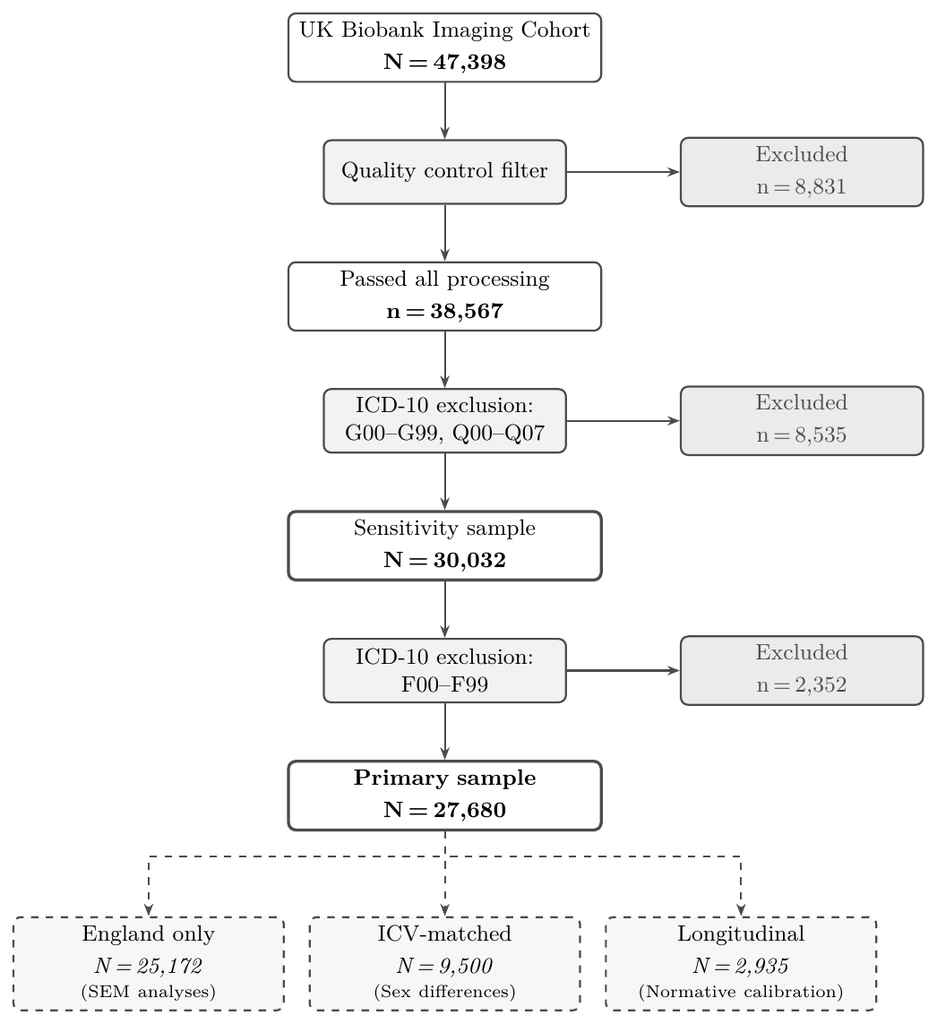

Fernández-Lozano, 2026

Chapter 5 · Methods compared

Four head-size adjustments

Each assumes something different about how brain volume scales with head size

| Adjustment | What it does |
| --- | --- |
| **Raw** | No correction — volumes in native space |
| **Proportions** | *V* / ICV — assumes isometric scaling |
| **Stereotaxic** | Warp to a common template — removes ICV spatially |
| **Residualized** | Linear regression removes the ICV component |

Chapter 5 · The geometric proof

Match on head size: HC collapses, HVR persists

d = 0.18

HVR female advantage in 4,750 head-size-matched pairs

Matched on age and head size, the raw HC difference collapses to ≈ 0 — but HVR stays significant. What remains is biology, not artifact.

Chapter 5 · The headline figure

HC reverses across methods · HVR doesn’t

4 adjustment methods  
(triangles = matched-pair subsample)

**HC** swings d = −0.89 → +0.58  
a **1.5-SD** range across methods.

**HVR** a single **self-normalized** value, d ≈ **+0.52** (female advantage) — no correction to choose.

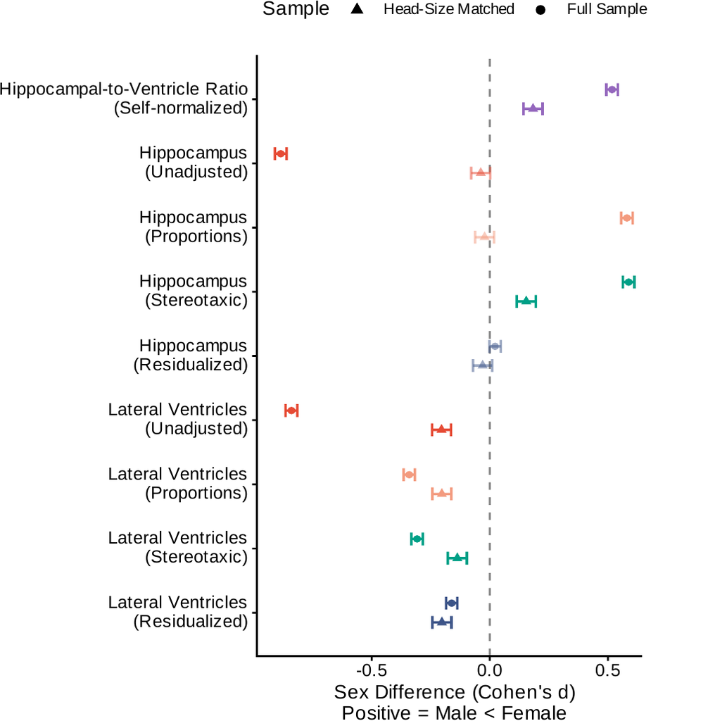

Fernández-Lozano, 2026

Chapter 5 · Trajectories

Males decline 1.7× faster in HVR

Cross-sectional age × sex

**HVR** male slope **1.7×** steeper than female.

Sits between **HC (1.4x)** and **LV (2x)**  
HVR captures both atrophy and ventricular expansion.

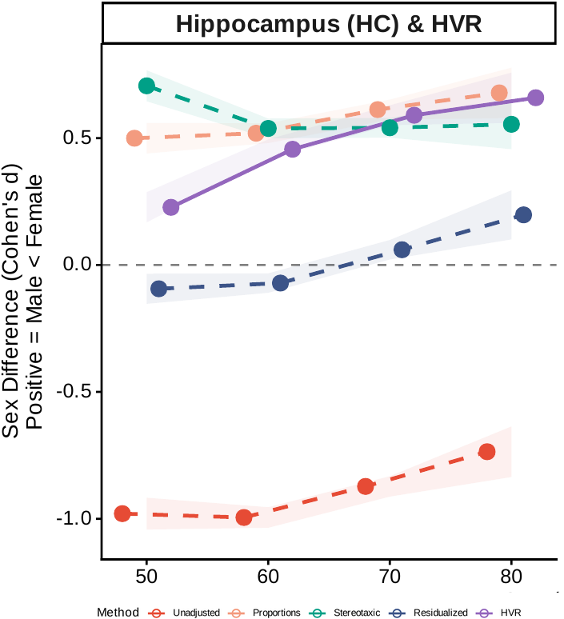

Fernández-Lozano, 2026

Chapter 5 · Functional validity

HVR predicts general cognition in both sexes; residualized HC fails in males

Standardized path → general cognition (g) · significance by sex

| Brain measure → g | Female | Male |
| --- | --- | --- |
| **HVR** | ✓ | ✓ |
| HC (Res) | ✓ | **✗** |
| HC (raw) | ✓ | ✓ |

✓ = standardized path significant (p < 0.05) · the linear ICV adjustment strips cognition-relevant signal in males; HVR’s self-normalization preserves it.

Fernández-Lozano, 2026

Chapter 5 · Normative reference

Sex-specific normative centile curves

Reference percentiles  
HVR / HC / LV by sex, ages 45–82

Well-calibrated on held-out 20%.

Transferred to ADNI in **Chapter 6**  
to z-score patients.

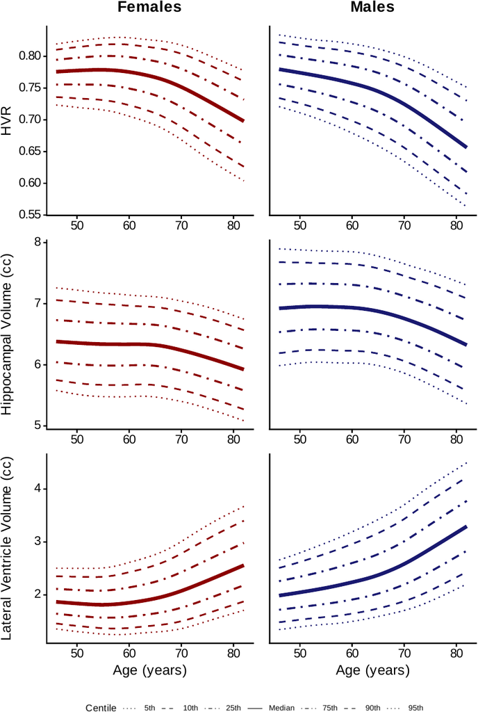

Fernández-Lozano, 2026

Chapter 6

Cardiovascular Risk and HVR‑Cognitive Coupling

Does cardiovascular risk drive brain–cognition decline — or just track age?

Fernández-Lozano S, Villeneuve S, Collins DL; for the ADNI. Cardiovascular risk and hippocampal-cognitive coupling in Alzheimer’s disease. *medRxiv* MEDRXIV/2026/354601; to be submitted to *Alzheimer’s & Dementia*. 2026

Chapter 6 · ADNI sample

Amyloid-positive primary cohort, amyloid-negative controls

Longitudinal MRI + cognition along the AD continuum

**Primary** — **N = 923** amyloid-positive.

**Control** — **N = 317** amyloid-negative,  
cognitively unimpaired.

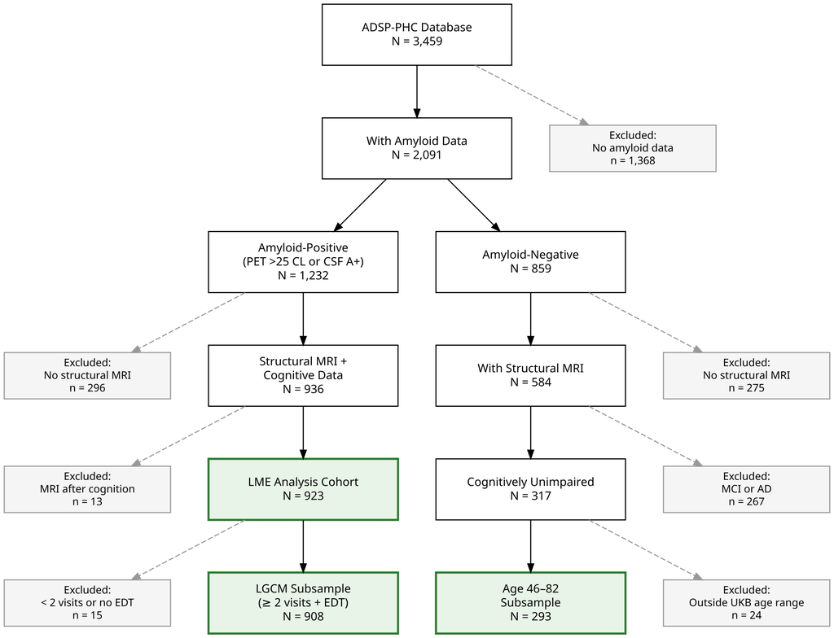

Fernández-Lozano, 2026

Chapter 6 · Bridge from Chapter 5

HVR z-scored against sex-specific normative model

Ch 5 GAMLSS centiles transferred from UKB to ADNI

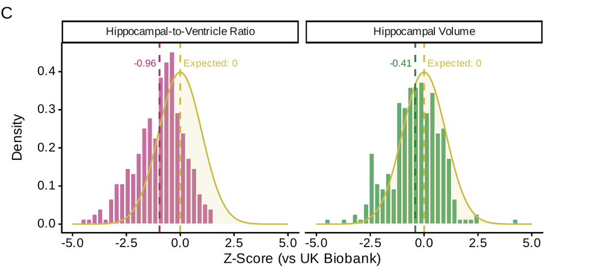

Fernández-Lozano, 2026

Chapter 6 · The problem with FRS in elderly cohorts

The Framingham Risk Score is the wrong instrument here

Dominated by age — and saturated — in an elderly cohort

3.06 / 2.33

FRS age coefficients (men / women) — log-hazard scale

Age is the heaviest input, so in ADNI it explains most of FRS variance.  
And FRS caps at 30%: **75% of women, 28% of men** pile up at that ceiling.

Chapter 6 · Methodology

Age is an internal weight, not an external confounder

**Covariate adjustment ✗**

- Regress age out of FRS *post-hoc*
- Removes only **shared variance**
- Age-weighting **still inside** the score

**MIMIC SEM ✓**  
Multiple Indicators, Multiple Causes

- Age as *cause* of a latent CVR factor
- BP · chol · diabetes · smoking → CVR
- Age partialled at the **latent level**, before the score exists

Chapter 6 · The MIMIC model

Latent CVR = γ · *Age*<sub>z</sub> + ζ

Age explains a tiny slice of latent cardiovascular risk — the residual ζ is CVR<sub>mimic</sub>

1.6%

of latent CVR variance explained by age (γ = 0.125)

CVR<sub>mimic</sub> is the age-orthogonal residual.  
It correlates **r ≈ 0.3–0.5** with FRS — same cardiovascular signal, age stripped.

Chapter 6 · Validation

CVR<sub>mimic</sub> is age-orthogonal by construction

FRS climbs with age (*r* = 0.33); CVR<sub>mimic</sub> is flat (*r* = 0.03)

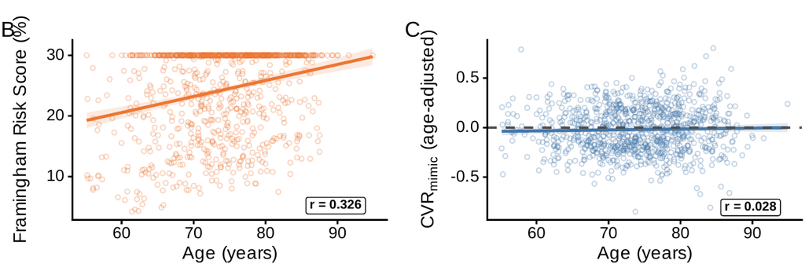

Same cardiovascular signal as FRS (*r* ≈ **0.3–0.5**) — age stripped.

Fernández-Lozano, 2026

Chapter 6 · Cognitive outcomes

Three ADSP-PHC composite scores

**Memory**  
WMS-R · AVLT  
ADAS-Cog recall

**Language**  
Category fluency  
Boston Naming

**Executive Function**  
Trail A/B  
Digit Span/Symbol

**Kang et al.** — bifactor item-banking harmonizes the composites across ADNI · ACT · ROS/MAP · NACC  
**This thesis** — the measurement-error SE is carried into the LGCM residual variance

Kang et al., 2023 (ADSP-PHC composites)

Chapter 6 · Q1 — does cardiovascular risk drive atrophy?

FRS predicts HVR decline; CVR<sub>mimic</sub> doesn’t

LGCM a-path (risk → HVR slope) · 6 models = 3 domains × 2 sexes

| Cognitive domain | FRS → HVR (F / M) | CVR<sub>mimic</sub> → HVR (F / M) |
| --- | --- | --- |
| Memory | ✓ / ✓ | ✗ / ✗ |
| Language | ✓ / ✓ | ✗ / ✗ |
| Executive | ✓ / ✓ | ✗ / ✗ |
| **Total** | **6 / 6** | **0 / 6** |

✓ = a-path bootstrap 95% CI excludes 0 · strip age from the score and the cardiovascular → atrophy effect vanishes.

Chapter 6 · Q2  
— does CVR modify HVR–Cog coupling?

Same pattern in moderation: FRS dominates, CVR<sub>mimic</sub> mostly null

3-way Years × CVR × HVR interaction

All **6 FRS effects** survive FDR correction.

CVR<sub>mimic</sub> sig in **Female Executive only**.

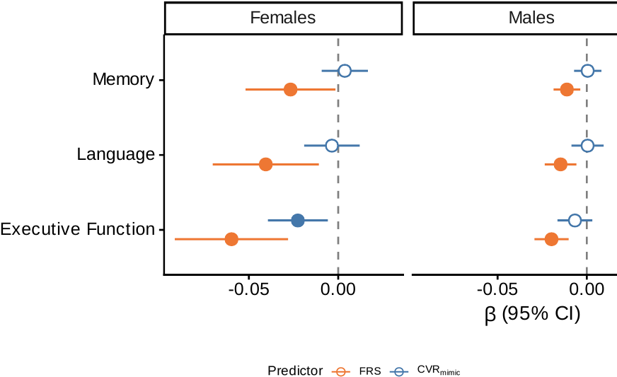

Fernández-Lozano, 2026

Chapter 6 · Pivotal sensitivity result

Without AD pathology,  
the pattern reverses

Amyloid-negative cognitively unimpaired (control) sample

**Amyloid-positive:**  
FRS survives correction · CVR<sub>mimic</sub> null.

Without amyloid driving atrophy,  
a **genuine cardiovascular signal** surfaces.

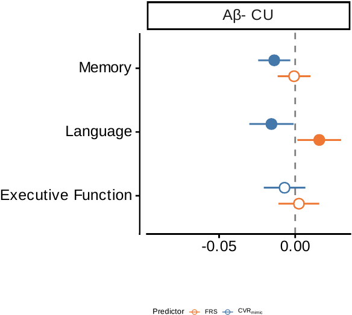

Fernández-Lozano, 2026

Chapter 6 · The robust finding

The divergence is upstream

The b-path (HVR slope → cognitive slope) is identical under both predictors

**FRS model** — b-path significant in **4 of 6** cells.  
**CVR<sub>mimic</sub> model** — significant in the **same 4 of 6** cells.

So FRS and CVR<sub>mimic</sub> diverge *only* on the a-path (**6 / 6** vs **0 / 6**). The downstream coupling — hippocampal decline → cognitive decline — is real and predictor-agnostic: a neurodegenerative signal, not vascular.

Fernández-Lozano, 2026

Chapter 6 · Interpretation

Moderation without mediation

A cognitive-reserve-like mechanism

**The puzzle** — CVR<sub>mimic</sub> doesn’t cause hippocampal decline, yet it still modifies the HVR–cognition link in some female models.

**Reserve framing** — cardiovascular burden reduces the brain’s **capacity to maintain** cognition at a given structural level — distinct from amyloid / tau.

**Implication** — a *modifiable*, reserve-like target.

Fernández-Lozano, 2026

Closing

Conclusions & Original Contributions

An end-to-end HVR pipeline, validated across two cohorts

Original contributions

What this thesis built

**Ch 3 — Qrater** Open-source, collaborative QC platform. *Aperture Neuro* 2024.

**Ch 4 — Automated HVR** CNN segmentation, Docker-deployed. *Human Brain Mapping* 2025.

**Ch 5 — Self-normalization + norms** Sex-difference reversal exposed as artifact; sex-specific GAMLSS centiles. *bioRxiv* 2026.

**Ch 6 — MIMIC framework** Age-adjusted CVR; FRS–brain link reflects age-weighting; HVR–cognitive coupling robust. In preparation.

Closing

From raw MRI to individualized brain-aging assessment

Quality-controlled imaging → automated HVR segmentation → sex-specific normative z-scores → clinical inference.

**Methodological vigilance is how artifacts are distinguished from biology.**

[figure not shown]

[figure not shown]

[figure not shown]

Acknowledgements

Thank you

My supervisor and my committee  
My coauthors, collaborators, and labmates  
My friends and family

**Funding:** CIHR · International Progressive MS Alliance · Famille Charron  
**Data:** the ADNI investigators · UK Biobank